# Autocompletado de frases del Presidente de la República utilizando modelos de n-gramas

El procesamiento de lenguaje natural (PLN) estudia las interacciones entre las computadoras y el lenguaje humano. Se ocupa de la formulación e investigación de mecanismos eficaces computacionalmente para la comunicación entre personas y máquinas por medio del lenguaje natural, es decir, de las lenguas del mundo. Entre los distintos modelos de PLN explicados en la asignatura respectiva en la Maestría en Ciencia de Datos se encuentran los modelos del lenguaje, en esta entrega estaremos utilizando de manera específica los modelos de n-gramas.

Un n-grama es un conjunto de n elementos consecutivos en un documento de texto o secuencias. Cabe aclarar. que el estudio de n-gramas no sólo se circunscribe al análisis de textos en PLN, dado que también tiene aplicaciones en otras disciplinas como el estudio de las secuencias de genes y en el estudio de las secuencias de aminoácidos.

Los n-gramas pueden tomar nombres según el número de elementos como son:

Unigramas (n=1)

Bigramas (n=2)

Trigramas (n=3)

Los modelos de n-gramas, por otro lado, permiten hacer predicciones sobre el siguiente elemento dada una secuencia.

Una de las ventajas de usar este tipo de modelos es la importancia que se le da al contexto en el que son utilizadas las palabras.

# Autocompletado de frases de las conferencias mañaneras

Uno de los principales usos de este tipo de modelos se encuentra en aplicaciones de predicción de texto como son utilizados en los procesadores de texto o en los teclados de los teléfonos móviles, por lo que se puede decir que todos los días convivimos con ellos.

Para mostrar su uso práctico, en el presente texto se elaborará un modelo a partir de las intervenciones del Presidente de la República, Andrés Manuel López Obrador, en las conferencias matutinas del 4 de diciembre de 2018 al 13 de mayo de 2021, ya procesadas por NOSTRODATA (repo).

La libreta para realizar el ejercicio está basada en el ejercicio de la semana 3 del curso Procesamiento de Lenguaje Natural con Modelos Probabilístas del Programa especializado: Procesamiento de lenguajes naturales de Deeplearning.ai en Coursera (liga).

Para el presente texto la definición de funciones ha sido obviada, pero la libreta se encuentra en el repositorio

## 1. Carga de datos y preprocesamiento

### 1.1 Carga de librerías y datos

```python
import math
import random
import numpy as np
import pandas as pd
import nltk
nltk.data.path.append('.')
```

```python
with open("./Datos/mananeras texto oraciones.csv", "r") as f:
    data = f.read()

print("Número de letras:", len(data))
print("Primeras 300 letras")
print("-------")
display(data[0:300])
print("-------")

print("Últimas 300 letras")
print("-------")
display(data[-300:])
print("-------")
```

```
Número de letras: 17233994
Primeras 300 letras
-------
```

```
'Muy buenos días.\n"¿Algo más, licenciado?"\n¿Cómo es Andrés Manuel?\n"¿Es todo, licenciado?"\n"¿Le puede poner una dedicatoria a mi papá, que le admira tanto?"\n¿Y a qué vienes si aquí tengo mi certificado?\n¿Y no le parece a usted que son muy corruptos?\n¿Y qué cargo quieres?\n"a lo mejor a eso se…
```

```
-------
Últimas 300 letras
-------
```

```
'conocer a los trabajadores pensionados con sus derechos."\nZoé y director del Infonavit.\n"Zoé, ¿por qué no le permites al representante de Coahuila que nos informe cómo va el plan de vacunación?"\nZoé.\nZoé.\nZoé.\nZoé.\nZona libre en los tres mil 180 kilómetros de frontera con Estados Unidos.\nZu…
```

### 1.2 Preprocesamiento de datos

Seguimos los siguientes pasos:

1. Separamos las oraciones utilizando "\n" comod delimitadorr.
2. Separamos cada oración en tokens (palabras).
3. Se asignan los datos en sents de entrenamiento y prueba.
4. Se encuentra cuantas veces aparecen los tokens en el set de entrenamiento.
5. Se reemplaza aquellos tokens que aparezcan menos de dos veces por `<unk>`

```python
def split_to_sentences(data):
    sentences = data.split("\n")

    sentences = [s.strip() for s in sentences]
    sentences = [s for s in sentences if len(s) > 0]

    return sentences
```

```python
def tokenize_sentences(sentences):

    tokenized_sentences = []

    for sentence in sentences:

        sentence = sentence.lower()

        tokenized = nltk.word_tokenize(sentence)

        tokenized_sentences.append(tokenized)

    return tokenized_sentences
```

```python
def get_tokenized_data(data):

    sentences = split_to_sentences(data)

    tokenized_sentences = tokenize_sentences(sentences)

    return tokenized_sentences
```

#### Se separan los datos en sets de entrenamiento y de prueba

```python
tokenized_data = get_tokenized_data(data)
random.seed(87)
random.shuffle(tokenized_data)

train_size = int(len(tokenized_data) * 0.8)
train_data = tokenized_data[0:train_size]
test_data = tokenized_data[train_size:]
```

```python
print("{} los datos son separados: {} observaciones en set de entrenamiento and {} en set de prueba".format(
    len(tokenized_data), len(train_data), len(test_data)))

print("Muestra del set de entrenamiento:")
print(train_data[0])

print("Muestra del set de prueba")
print(test_data[0])
```

```
130871 los datos son separados: 104696 observaciones en set de entrenamiento and 26175 en set de prueba
Muestra del set de entrenamiento:
['nos', 'vemos', 'mañana', '.']
Muestra del set de prueba
['``', ':', 'a', 'ver', ',', 'no', 'vamos', 'a', 'triangular', ';', 'directo', ',', 'por', 'alusiones', 'personales', ',', 'bueno', '.', "''"]
```

```python
### Se realiza la limpieza de tokens
```

```python
def count_words(tokenized_sentences):

    word_counts = {}

    for sentence in tokenized_sentences:
        for token in sentence:

            if token in word_counts:
                 word_counts[token] += 1

            else:
                 word_counts[token] = 1


    return word_counts
```

```python
def get_words_with_nplus_frequency(tokenized_sentences, count_threshold):

    closed_vocab = []

    word_counts = count_words(tokenized_sentences)

    for word, cnt in word_counts.items():

        if cnt >= count_threshold:

            closed_vocab.append(word)

    return closed_vocab
```

```python
def replace_oov_words_by_unk(tokenized_sentences, vocabulary, unknown_token="<unk>"):

    vocabulary = set(vocabulary)

    replaced_tokenized_sentences = []

    for sentence in tokenized_sentences:

        replaced_sentence = []

        for token in sentence:

            if token in vocabulary:
                replaced_sentence.append(token)
            else:

                replaced_sentence.append(unknown_token)

        replaced_tokenized_sentences.append(replaced_sentence)

    return replaced_tokenized_sentences
```

#### Se procesan nuestros datos utilizando las funciones antes definidas

1. Encuentra tokens que aparecen menos de 2 veces.
2. Se reemplazan estos tokens por "<unk>" tanto en el set de entrenamiento como en el de prueba.

```python
def preprocess_data(train_data, test_data, count_threshold):

    vocabulary = get_words_with_nplus_frequency(train_data,count_threshold)

    train_data_replaced = replace_oov_words_by_unk(train_data,vocabulary)

    test_data_replaced = replace_oov_words_by_unk(test_data,vocabulary)

    return train_data_replaced, test_data_replaced, vocabulary
```

```python
minimum_freq = 2
train_data_processed, test_data_processed, vocabulary = preprocess_data(train_data,
                                                                        test_data,
                                                                        minimum_freq)
```

```python
print("Muestra del set de entrenamiento preprocesado:")
print(train_data_processed[2])
print()
print("Muestra del set de prueba preprocesado:")
print(test_data_processed[3])
print()
print("Primeros 10 tokens en vocabulario:")
print(vocabulary[0:10])
print()
print("Tamaño del vocabulario:", len(vocabulary))
```

```
Muestra del set de entrenamiento preprocesado:
['coloquialmente', 'grilla', 'o', 'más', 'elegantemente', 'politiquería', '.']

Muestra del set de prueba preprocesado:
['``', 'a', 'nivel', 'mundial', 'y', 'de', 'estados', 'unidos', 'que', 'hay', ',', 'en', 'efecto', ',', 'alrededor', 'de', '38', 'millones', 'de', 'mexicanos', 'nacidos', 'aquí', 'muchos', 'y', 'otros', 'hijos', 'de', 'mexicanos', ',', '25', 'mil', '<unk>', '.', "''"]

Primeros 10 tokens en vocabulario:
['nos', 'vemos', 'mañana', '.', '``', 'se', 'está', 'trabajando', 'en', '94']

Tamaño del vocabulario: 23305
```

### Nube de palabras

```python
from nltk.corpus import stopwords
from string import punctuation
nltk.download("stopwords")
stoplist =  set(stopwords.words('spanish') + list(punctuation) + ['``',"''", "nos","vemos","mañana", "como","cómo"])
vocabulary = [w for w in vocabulary if not w in stoplist]
```

```python
from wordcloud import WordCloud
import matplotlib.pyplot as plt
text = " ".join(w for w in vocabulary)
wordcloud = WordCloud(stopwords=stoplist, background_color="white").generate(text)
```

```python
def plot_cloud(wordcloud):
    # Set figure size
    plt.figure(figsize=(40, 30))
    # Display image
    plt.imshow(wordcloud)
    # No axis details
    plt.axis("off");
```

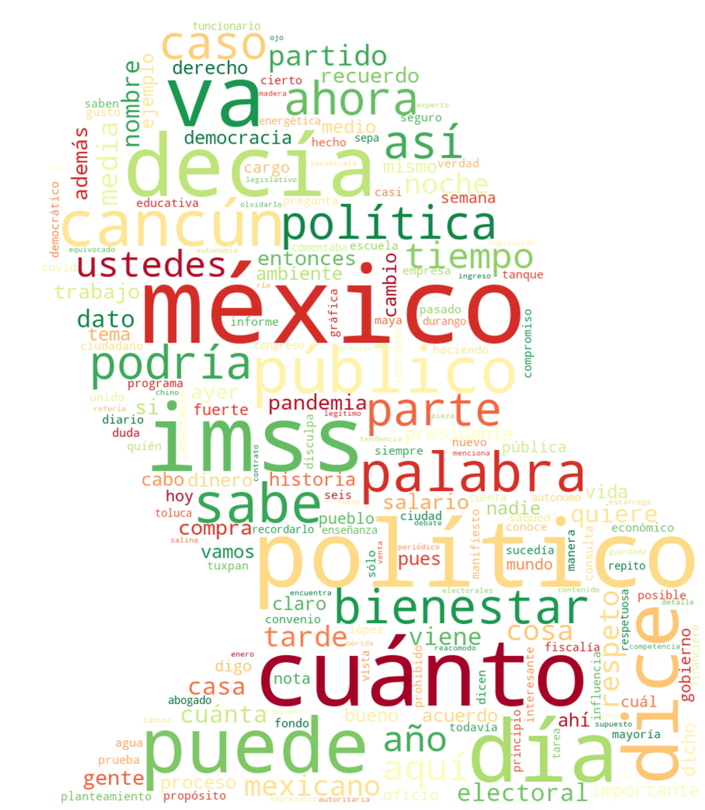

```python
# Import packages
from PIL import Image
import urllib
import requests
# Import image to np.array
mask = np.array(Image.open(requests.get('https://www.unimediosagencia.com/wp-content/uploads/2013/12/AMLO.jpg', stream=True).raw))
# Generate wordcloud
wordcloud = WordCloud(width = 3000, height = 2000, random_state=1, background_color='white', colormap='RdYlGn', contour_width=4, contour_color='white', collocations=False, stopwords = stoplist, mask=mask).generate(text)
# Plot
plot_cloud(wordcloud)
plt.savefig('amlo.png')
```

## 2. Se desarrolla el modelo de n-gramas

- Para el desarrollo del modelo se asume que la probabilidad de la ocurrencia de una palabra depende de las que le anteceden.

La probabilidad condicional de una palabra en la posición 't' en una oración, dado que las palabras que le anteceden son $w_{t-1}, w_{t-2} \cdots w_{t-n}$ es:

$$ P(w_t | w_{t-1}\dots w_{t-n}) \tag{1}$$

Se puede estimar la probabilidad contando las ocurrencias de éstas dentro de la serie de palabas en el set de entrenamiento.

$$ \hat{P}(w_t | w_{t-1}\dots w_{t-n}) = \frac{C(w_{t-1}\dots w_{t-n}, w_n)}{C(w_{t-1}\dots w_{t-n})} \tag{2} $$

Para realizar lo anterior, se definen algunas funciones.

```python
def count_n_grams(data, n, start_token='<s>', end_token = '<e>'):

    n_grams = {}

    for sentence in data:

        sentence = [start_token] * n+ sentence + [end_token]

        sentence = tuple(sentence)

        for i in range(0, len(sentence)-n+1):
            n_gram = sentence[i:i+n]

            if n_gram in n_grams.keys():

                n_grams[n_gram] += 1
            else:

                n_grams[n_gram] = 1

    return n_grams
```

```python
def estimate_probability(word, previous_n_gram,
                         n_gram_counts, n_plus1_gram_counts, vocabulary_size, k=1.0):

    previous_n_gram = tuple(previous_n_gram)

    previous_n_gram_count = n_gram_counts[previous_n_gram] if previous_n_gram in n_gram_counts  else 0

    denominator = previous_n_gram_count + k * vocabulary_size

    n_plus1_gram = previous_n_gram + (word,)

    n_plus1_gram_count = n_plus1_gram_counts[n_plus1_gram] if n_plus1_gram in n_plus1_gram_counts  else 0

    numerator = n_plus1_gram_count + k

    probability = numerator / denominator

    return probability
```

```python
def estimate_probabilities(previous_n_gram, n_gram_counts, n_plus1_gram_counts, vocabulary, k=1.0):

    previous_n_gram = tuple(previous_n_gram)

    vocabulary = vocabulary + ["<e>", "<unk>"]
    vocabulary_size = len(vocabulary)

    probabilities = {}
    for word in vocabulary:
        probability = estimate_probability(word, previous_n_gram,
                                           n_gram_counts, n_plus1_gram_counts,
                                           vocabulary_size, k=k)
        probabilities[word] = probability

    return probabilities
```

### Se definen las matrices de conteo y de probabilidad

```python
def make_count_matrix(n_plus1_gram_counts, vocabulary):

    vocabulary = vocabulary + ["<e>", "<unk>"]

    n_grams = []
    for n_plus1_gram in n_plus1_gram_counts.keys():
        n_gram = n_plus1_gram[0:-1]
        n_grams.append(n_gram)
    n_grams = list(set(n_grams))

    row_index = {n_gram:i for i, n_gram in enumerate(n_grams)}

    col_index = {word:j for j, word in enumerate(vocabulary)}

    nrow = len(n_grams)
    ncol = len(vocabulary)
    count_matrix = np.zeros((nrow, ncol))
    for n_plus1_gram, count in n_plus1_gram_counts.items():
        n_gram = n_plus1_gram[0:-1]
        word = n_plus1_gram[-1]
        if word not in vocabulary:
            continue
        i = row_index[n_gram]
        j = col_index[word]
        count_matrix[i, j] = count

    count_matrix = pd.DataFrame(count_matrix, index=n_grams, columns=vocabulary)
    return count_matrix
```

```python
def make_probability_matrix(n_plus1_gram_counts, vocabulary, k):
    count_matrix = make_count_matrix(n_plus1_gram_counts, unique_words)
    count_matrix += k
    prob_matrix = count_matrix.div(count_matrix.sum(axis=1), axis=0)
    return prob_matrix
```

### 2.1 Perplejidad

Para evaluar el modelo se calcula la perplejidad, la cual es una medida de cómo modelo de probabilidad predice una muestra. Para calcularla se define de la siguiente manera

$$ PP(W) =\sqrt[N]{ \prod_{t=n+1}^N \frac{1}{P(w_t | w_{t-n} \cdots w_{t-1})} } \tag{4}$$

Si las probabilidades son altas, la perplejidad será más baja.

Se calcula la perplejidad dada un matriz de conteo de n-gramas y una oración.

```python
def calculate_perplexity(sentence, n_gram_counts, n_plus1_gram_counts, vocabulary_size, k=1.0):
    n = len(list(n_gram_counts.keys())[0])

    sentence = ["<s>"] * n + sentence + ["<e>"]

    sentence = tuple(sentence)

    N = len(sentence)

    product_pi = 1.0

    for t in range(n, N): # complete this line

        n_gram = sentence[t-n:t]

        word = sentence[t]
        probability = estimate_probability(word, n_gram, n_gram_counts, n_plus1_gram_counts, vocabulary_size, k=1.0)

        product_pi *= (1/probability)

    perplexity =  product_pi ** (1/N)

    return perplexity
```

## 3. Se construye el modelo de autocompletado

```python
def suggest_a_word(previous_tokens, n_gram_counts, n_plus1_gram_counts, vocabulary, k=1.0, start_with=None):

    n = len(list(n_gram_counts.keys())[0])

    previous_n_gram = previous_tokens[-n:]

    probabilities = estimate_probabilities(previous_n_gram,
                                           n_gram_counts, n_plus1_gram_counts,
                                           vocabulary, k=k)

    suggestion = None

    max_prob = 0

    for word, prob in probabilities.items():

        if start_with != None:
            if word.startswith(start_with) == False:

                continue

        if prob > max_prob:

            suggestion = word

            max_prob = prob

    return suggestion, max_prob
```

### Obtenemos múltiples sugerencias

Mediante la siguiente función podemos tomar sugerencias de distintos modelos de n-gramas.

```python
def get_suggestions(previous_tokens, n_gram_counts_list, vocabulary, k=1.0, start_with=None):
    model_counts = len(n_gram_counts_list)
    suggestions = []
    for i in range(model_counts-1):
        n_gram_counts = n_gram_counts_list[i]
        n_plus1_gram_counts = n_gram_counts_list[i+1]

        suggestion = suggest_a_word(previous_tokens, n_gram_counts,
                                    n_plus1_gram_counts, vocabulary,
                                    k=k, start_with=start_with)
        suggestions.append(suggestion)
    return suggestions
```

### Ponemos en práctica el modelo

```python
n_gram_counts_list = []
for n in range(1, 5):
    print("Computing n-gram counts with n =", n, "...")
    n_model_counts = count_n_grams(train_data_processed, n)
    n_gram_counts_list.append(n_model_counts)
```

```
Computing n-gram counts with n = 1 ...
Computing n-gram counts with n = 2 ...
Computing n-gram counts with n = 3 ...
Computing n-gram counts with n = 4 ...
```

#### Frase: La mafia del poder

```python
previous_tokens = ["la", "mafia","del"]
tmp_suggest1 = get_suggestions(previous_tokens, n_gram_counts_list, vocabulary, k=1.0)

print(f"Las palabras previas son {previous_tokens}, las sugerencias son:")
display(tmp_suggest1)
```

```
Las palabras previas son ['la', 'mafia', 'del'], las sugerencias son:
```

```
[('gobierno', 0.02739759567122885),
 ('poder', 0.0005632338286902647),
 ('poder', 0.0005199306759098787)]
```

#### Frase: La patria es

```python
previous_tokens = ["la", "patria", "es"]
tmp_suggest2 = get_suggestions(previous_tokens, n_gram_counts_list, vocabulary, k=1.0)

print(f"Las palabras previas son {previous_tokens}, las sugerencias son:")
display(tmp_suggest2)
```

```
Las palabras previas son ['la', 'patria', 'es'], las sugerencias son:
```

```
[('decir', 0.0120288435286749),
 ('primero', 0.00030337176042298693),
 ('primero', 0.00030337176042298693)]
```

#### Frase: Por el bien de todos primero los

```python
previous_tokens = ["por", "el", "bien","de","todos", "primero", "los"]
tmp_suggest3 = get_suggestions(previous_tokens, n_gram_counts_list, vocabulary, k=1.0)

print(f"Las palabras previas son {previous_tokens}, las sugerencias son:")
display(tmp_suggest3)
```

```
Las palabras previas son ['por', 'el', 'bien', 'de', 'todos', 'primero', 'los'], las sugerencias son:
```

```
[('trabajadores', 0.016834585382262016),
 ('pobres', 0.0018164518640256034),
 ('pobres', 0.00043333188889370367)]
```

#### Frase: Delitos

```python
previous_tokens = ["delitos"]
tmp_suggest4 = get_suggestions(previous_tokens, n_gram_counts_list, vocabulary, k=1.0)

print(f"Las palabras previas son {previous_tokens}, las sugerencias son:")
display(tmp_suggest4)
```

```
Las palabras previas son ['delitos'], las sugerencias son:
```

```
[('electorales', 0.002041771236547705),
 ('trabajando', 4.3350095370209814e-05),
 ('trabajando', 4.3350095370209814e-05)]
```

#### Frase: Secretario de Relaciones Exteriores Marcelo

```python
previous_tokens = ["secretario", "relaciones", "exteriores", "marcelo"]
tmp_suggest5 = get_suggestions(previous_tokens, n_gram_counts_list, vocabulary, k=1.0)

print(f"Las palabras previas son {previous_tokens}, las sugerencias son:")
display(tmp_suggest5)
```

```
Las palabras previas son ['secretario', 'relaciones', 'exteriores', 'marcelo'], las sugerencias son:
```

```
[('ebrard', 0.007907672579611029),
 ('ebrard', 0.00021671289875173372),
 ('ebrard', 0.00021671289875173372)]
```

#### Frase: Ya no hay

```python
previous_tokens = ["ya", "no", "hay"]
tmp_suggest6 = get_suggestions(previous_tokens, n_gram_counts_list, vocabulary, k=1.0)

print(f"Las palabras previas son {previous_tokens}, las sugerencias son:")
display(tmp_suggest6)
```

```
Las palabras previas son ['ya', 'no', 'hay'], las sugerencias son:
```

```
[('corrupción', 0.004685131597078683),
 ('ningún', 0.006094522595730002),
 ('corrupción', 0.0010656436487638534)]
```

```python
previous_tokens = ["liberales"]
tmp_suggest7 = get_suggestions(previous_tokens, n_gram_counts_list, vocabulary, k=1.0)

print(f"Las palabras previas son {previous_tokens}, las sugerencias son:")
display(tmp_suggest7)
```

```
Las palabras previas son ['liberales'], las sugerencias son:
```

```
[('moderados', 0.00012955045990413266),
 ('trabajando', 4.3350095370209814e-05),
 ('trabajando', 4.3350095370209814e-05)]
```

```python
previous_tokens = ["los", "políticos"]
tmp_suggest8 = get_suggestions(previous_tokens, n_gram_counts_list, vocabulary, k=1.0)

print(f"Las palabras previas son {previous_tokens}, las sugerencias son:")
display(tmp_suggest8)
```

```
Las palabras previas son ['los', 'políticos'], las sugerencias son:
```

```
[('corruptos', 0.000978765053832078),
 ('corruptos', 0.0006464959917248513),
 ('trabajando', 4.3350095370209814e-05)]
```

```python
previous_tokens = ["el", "pueblo"]
tmp_suggest9 = get_suggestions(previous_tokens, n_gram_counts_list, vocabulary, k=1.0)

print(f"Las palabras previas son {previous_tokens}, las sugerencias son:")
display(tmp_suggest9)
```

```
Las palabras previas son ['el', 'pueblo'], las sugerencias son:
```

```
[('pobre', 0.00189042789108227),
 ('pone', 0.001262369181903327),
 ('trabajando', 4.3350095370209814e-05)]
```

#### Frase: Me canso

```python
previous_tokens = ["Me","canso"]
tmp_suggest10 = get_suggestions(previous_tokens, n_gram_counts_list, vocabulary, k=1.0)

print(f"Las palabras previas son {previous_tokens}, las sugerencias son:")
display(tmp_suggest10)
```

```
Las palabras previas son ['Me', 'canso'], las sugerencias son:
```

```
[('ganso', 0.001082485386447283),
 ('trabajando', 4.3350095370209814e-05),
 ('trabajando', 4.3350095370209814e-05)]
```